# Practical Machine Learning - Project

Rekha Nair

September 25, 2015

##### Report Summary: We have data collected by different activity devices like Fitbit, Jawbone etc. The goal of this project is to clean, explore, analyze and predict the outcomes using different prediction models as discussed in the class. I have used the CART(rpart) and RandomForest as my prediction model. The conclusion based off the analysis, is, that the RandomForest as expected provides a better accuracy than rpart.in predicting the outcome.

```r
set.seed(12345)

## Load the required libraries

library(caret)
library(rpart)
library(rattle)
library(randomForest)
## Read the data
## Training set

training <- read.csv("pml-training.csv", na.strings = "NA", header=TRUE)
```

##### CreateDataPartition on the original training set. This is because we need to first analyze on the subset of the training set which we will then use to validate against the rest of the data from the training set i.e the testing subset.

```r
## Cleaning the data as required.
inTrain <- createDataPartition(y=training$classe, p=0.7, list=FALSE)
subsetnewTrainingData <- training[inTrain, ]
subsetnewTestingData <- training[-inTrain,]

##Find out data with near zero variance
nzv <- nearZeroVar(subsetnewTrainingData)
filteredTrainingData <- subsetnewTrainingData[, -nzv]

##Training Data subset(delete any column with NA's)
newTrainingData <- filteredTrainingData[ , ! apply( filteredTrainingData , 2 , function(x) mean(is.na(x) > 0.95) ) ]

newTrainingData <- newTrainingData[,(-1)]


##Find out data with near zero variance  on the testing subset
nzv <- nearZeroVar(subsetnewTestingData)
filteredTestingData <- subsetnewTestingData[, -nzv]

##Training Data subset(delete any column with NA's)
newTestingData <- filteredTestingData[ , ! apply( filteredTestingData , 2 , function(x) any(is.na(x)) > 0.95) ]

## Taking out the first column X.
newTestingData <- newTestingData[,(-1)]

## Prediction based off rpart
rpartFit = rpart(classe ~ . , method="class", data=newTrainingData)
printcp(rpartFit)
```

```
##
## Classification tree:
## rpart(formula = classe ~ ., data = newTrainingData, method = "class")
##
## Variables actually used in tree construction:
##  [1] accel_forearm_x      cvtd_timestamp       magnet_belt_y
##  [4] magnet_dumbbell_x    magnet_dumbbell_z    num_window
##  [7] pitch_belt           raw_timestamp_part_1 roll_belt
## [10] roll_dumbbell        user_name
##
## Root node error: 9831/13737 = 0.71566
##
## n= 13737
##
##          CP nsplit rel error  xerror      xstd
## 1  0.256841      0   1.00000 1.00000 0.0053780
## 2  0.103652      1   0.74316 0.74387 0.0059485
## 3  0.059404      2   0.63951 0.64236 0.0059416
## 4  0.055233      3   0.58010 0.59506 0.0058951
## 5  0.049385      5   0.46964 0.50687 0.0057320
## 6  0.047961      7   0.37087 0.46394 0.0056145
## 7  0.020344      9   0.27495 0.28593 0.0048097
## 8  0.020039     10   0.25460 0.25654 0.0046156
## 9  0.014749     11   0.23456 0.23792 0.0044811
## 10 0.013732     12   0.21981 0.22195 0.0043578
## 11 0.011189     13   0.20608 0.20568 0.0042239
## 12 0.010000     15   0.18370 0.18767 0.0040652
```

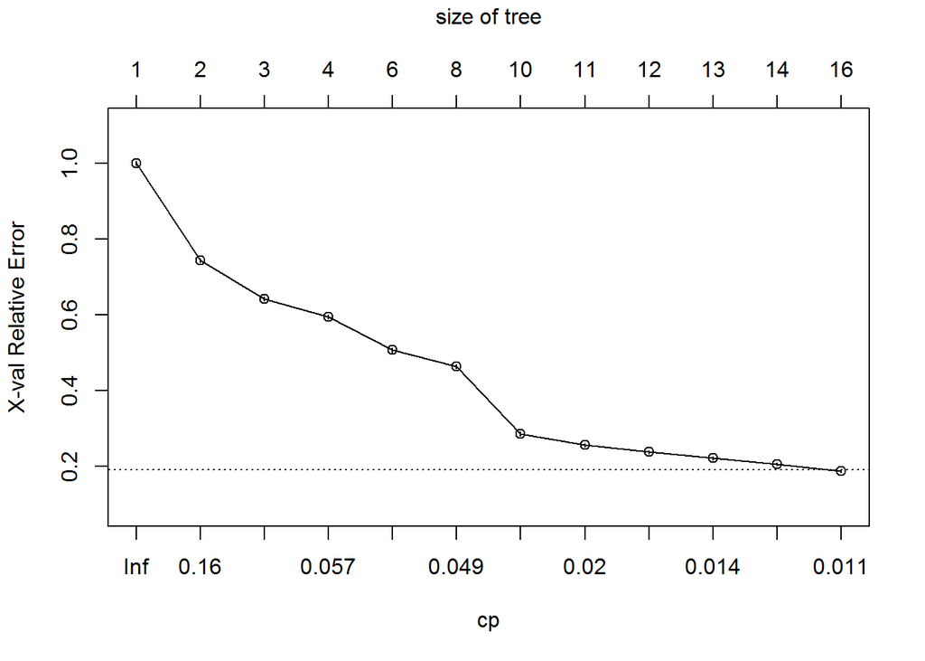

```r
# visualize cross-validation results
plotcp(rpartFit)
```

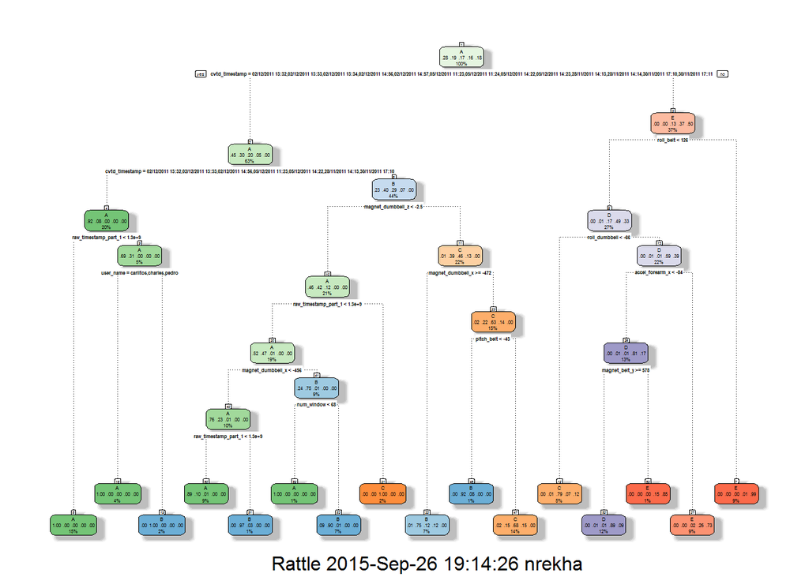

```r
# plot tree
fancyRpartPlot(rpartFit)
```

```r
predictionrPart <- predict(rpartFit, newTestingData, type = "class")
confusionMatrix(predictionrPart, newTestingData$classe)
```

```
## Confusion Matrix and Statistics
##
##           Reference
## Prediction    A    B    C    D    E
##          A 1620   44    3    1    0
##          B   38  950   76   41    0
##          C   16  137  931  157   47
##          D    0    8   10  598   55
##          E    0    0    6  167  980
##
## Overall Statistics
##
##                Accuracy : 0.863
##                  95% CI : (0.854, 0.8717)
##     No Information Rate : 0.2845
##     P-Value [Acc > NIR] : < 2.2e-16
##
##                   Kappa : 0.8267
##  Mcnemar's Test P-Value : NA
##
## Statistics by Class:
##
##                      Class: A Class: B Class: C Class: D Class: E
## Sensitivity            0.9677   0.8341   0.9074   0.6203   0.9057
## Specificity            0.9886   0.9673   0.9265   0.9852   0.9640
## Pos Pred Value         0.9712   0.8597   0.7228   0.8912   0.8500
## Neg Pred Value         0.9872   0.9605   0.9793   0.9298   0.9784
## Prevalence             0.2845   0.1935   0.1743   0.1638   0.1839
## Detection Rate         0.2753   0.1614   0.1582   0.1016   0.1665
## Detection Prevalence   0.2834   0.1878   0.2189   0.1140   0.1959
## Balanced Accuracy      0.9782   0.9007   0.9170   0.8027   0.9349
```

```r
## Prediction based off Random Forest
rfFitModel  <- randomForest(classe ~ .,data=newTrainingData,mtry=10,importance=TRUE)

predictionRF <- predict(rfFitModel, newTestingData, type = "class")
confusionMatrix(predictionRF, newTestingData$classe)
```

```
## Confusion Matrix and Statistics
##
##           Reference
## Prediction    A    B    C    D    E
##          A 1674    1    0    0    0
##          B    0 1138    2    0    0
##          C    0    0 1022    1    0
##          D    0    0    2  963    2
##          E    0    0    0    0 1080
##
## Overall Statistics
##
##                Accuracy : 0.9986
##                  95% CI : (0.9973, 0.9994)
##     No Information Rate : 0.2845
##     P-Value [Acc > NIR] : < 2.2e-16
##
##                   Kappa : 0.9983
##  Mcnemar's Test P-Value : NA
##
## Statistics by Class:
##
##                      Class: A Class: B Class: C Class: D Class: E
## Sensitivity            1.0000   0.9991   0.9961   0.9990   0.9982
## Specificity            0.9998   0.9996   0.9998   0.9992   1.0000
## Pos Pred Value         0.9994   0.9982   0.9990   0.9959   1.0000
## Neg Pred Value         1.0000   0.9998   0.9992   0.9998   0.9996
## Prevalence             0.2845   0.1935   0.1743   0.1638   0.1839
## Detection Rate         0.2845   0.1934   0.1737   0.1636   0.1835
## Detection Prevalence   0.2846   0.1937   0.1738   0.1643   0.1835
## Balanced Accuracy      0.9999   0.9994   0.9979   0.9991   0.9991
```

```r
## Testing set
training <- read.csv("pml-training.csv", na.strings = "NA", header=TRUE)
filterTrainingData <- training[,-nzv]
originalTrainingData <- filterTrainingData[ , ! apply( filterTrainingData , 2 , function(x) mean(is.na(x) > 0.95) ) ]

testing <- read.csv("pml-testing.csv", na.strings = "NA", header=TRUE)
filteresTestingData <- testing[,-nzv]
originalTestingData <- filteresTestingData[ , ! apply( filteresTestingData , 2 , function(x) mean(is.na(x) > 0.95) ) ]


train <- originalTrainingData[, -(1)]
test <- originalTestingData[, -(1)]

# re-fit model using full training set
```

##### Cross validation method with 3 folds is specified using the trainControl method. Training the data using method “rf”

```r
fitControl <- trainControl(method="cv", number=3, verboseIter=F)
modelforPrediction <- train(classe ~ ., data=train, method="rf", trControl=fitControl)
```

##### Conclusion - RandomForest provides a 99% accuracy as compared to 86% from rpart model. The RandomForest model has been selected for the prediction of the original test data.

```r
##Prediction on original testing data, based on RandomForest model
# predict(modelforPrediction, newdata=test)
#[1] B A B A A E D B A A B C B A E E A B B B
#Levels: A B C D E
```